# Lab 4

Drew Hoffman, Tanner Ball, Burke Parent, David Washburn, Brandon Nelsen

9/20/2019

**1. Overall Questions:** 1. Does smoking have an effect on gestational length? While this question is pretty basic, it’s important to establish a basis for what we hope to analyze. Asking this question can help guide us towards what we want to show using data.

2. Could there be an underlying variable that is related to gestational length and smoking? As data scientists we want to consider that there could be other related factors that aren’t immediately apparent in the data.
3. Where are these data coming from?  
   When analyzing a set of data it is important to ensure that it comes from a credible source. We also want to consider when the survey was done and how the survey for the data was conducted (in case of bias).

**2. Team Plots:**

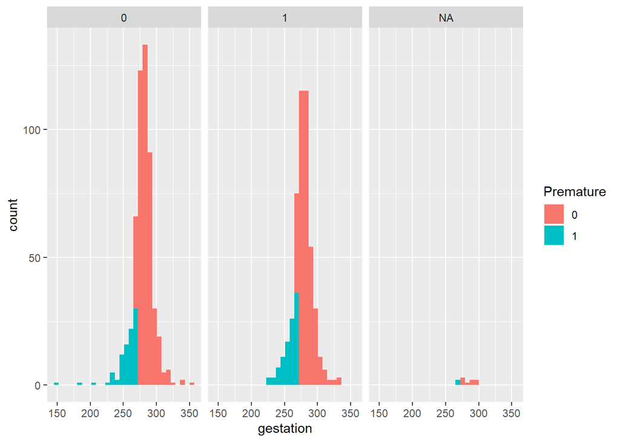

```r
babies$Premature <- as.numeric(babies$Premature)
babies$Premature <- as.factor(babies$Premature)
ggplot(data = babies, mapping = aes(x = gestation, fill = Premature))+
  geom_histogram()+
  facet_wrap(~smoke)
```

**Analysis of Premature Births** This is a histogram of gestation age between smokers and non smokers, the Surgeon General’s first assertion that “Mothers who smoke have increased rates of premature delivery” is not supported. There is little to no difference between a mother having smoked and having not smoked and the baby’s delivery date.

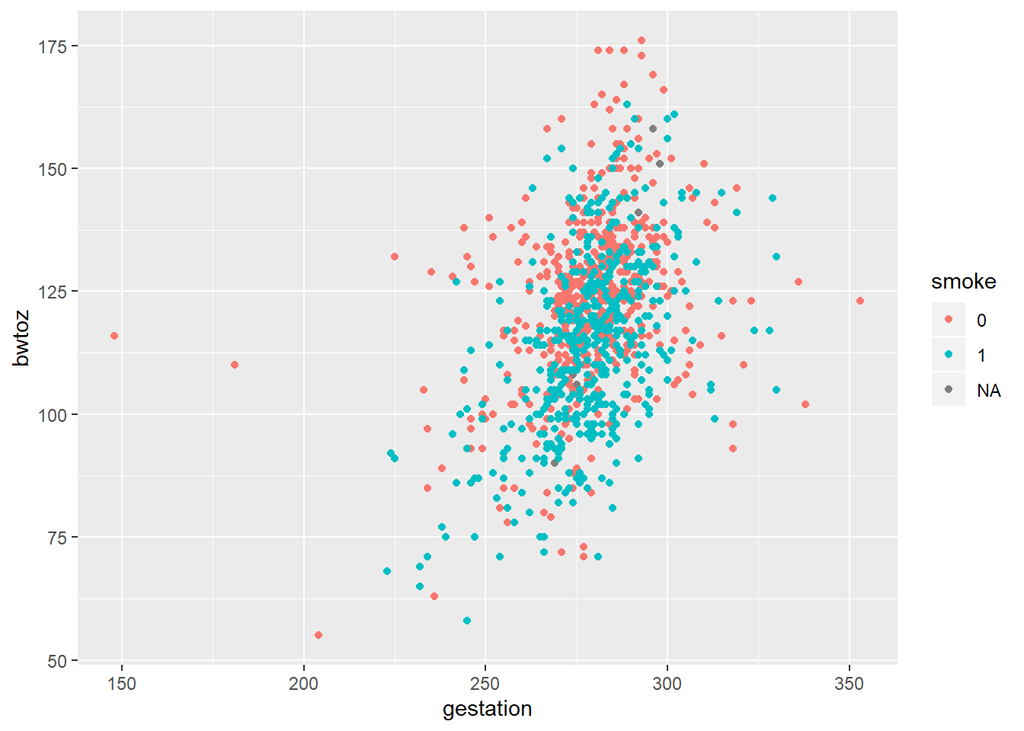

```r
babies$smoke <- as.numeric(babies$smoke)
babies$smoke <- as.factor(babies$smoke)
ggplot(data = babies, mapping = aes(x = gestation, y = bwtoz, color = smoke))+
  geom_point()
```

**Analysis of birth weights at gestational ages** This is a scatter plot of the birth weights against gestational ages of babies seperated by color of smoking and non smoking mothers. The Surgeon General’s second assertion that “newborns of mothers who smoke have smaller birth weights at every gestational age” is not supported. The data overlaps between smokers and non smokers and no distinction that birth weights are smaller at every gestational age can be seen by the scatter plot.

**4. Preliminary Question:**

Which variables are similar and different between smokers and non-smokers?

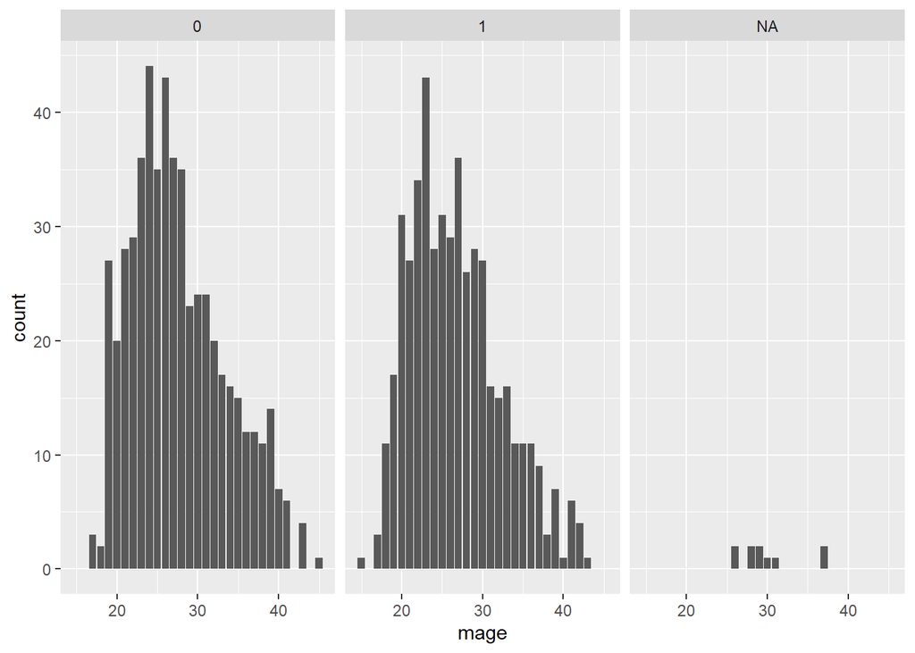

```r
ggplot(data = babies, mapping = aes(x = mage)) + geom_bar() + facet_wrap(~smoke)
```

In this scatterplot, the x-axis is labeled with the mother’s height and the y-axis is labeled with the mother’s weight. The two groups represent non-smokers (0) and smokers (1). As you may see, smokers tend to have a slightly lower body weight than non-smokers at the same height. This is most likely an effect of smoking cigarettes and may be an indication or hidden variable for why smokers tend to give birth to babies with lower birth weight.

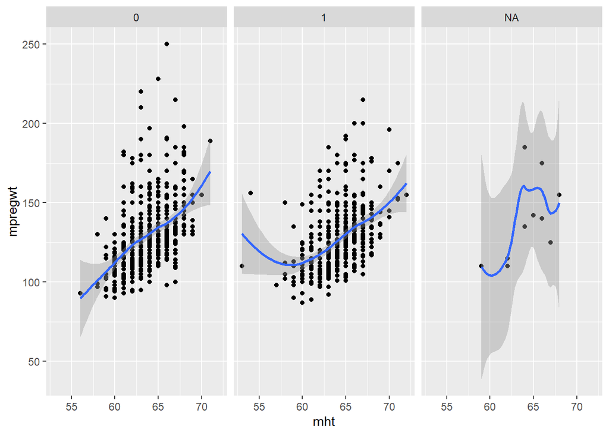

```r
ggplot(data = babies, mapping = aes(x = mht, y = mpregwt)) + geom_point() + facet_wrap(~smoke) + geom_smooth()
```

These two bar graphs are again divided between non-smokers(0) and smokers(1). The categorization is by income and as you can see, the income distributions are farily similar to each other and are within the error. This is an example of a variable that is similar between the two groups and will not lead to hidden effects on our results.

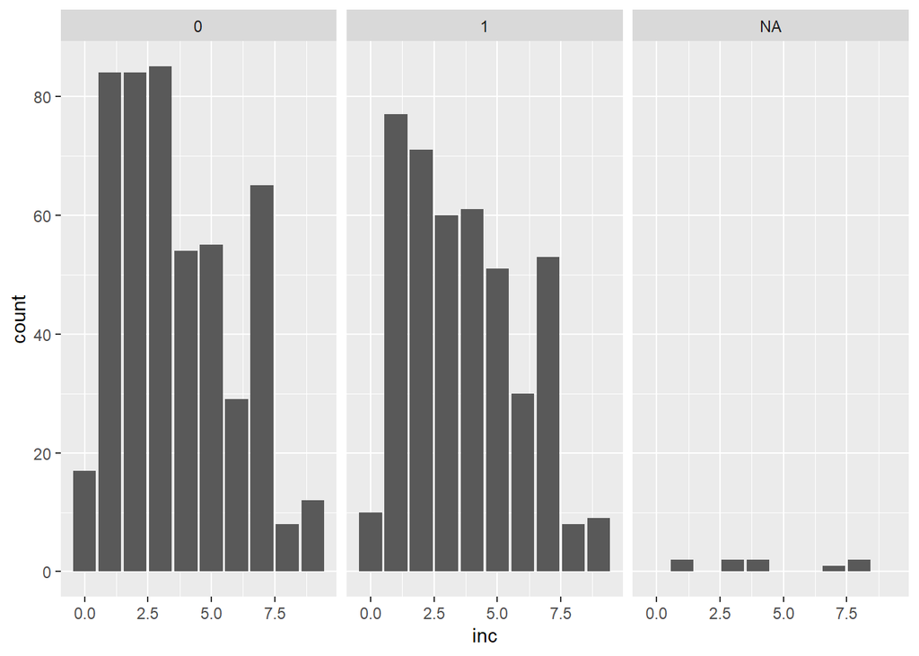

```r
ggplot(data = babies, mapping = aes(x = inc)) + geom_bar() + facet_wrap(~smoke)
```

**5. Individual Graphs:**

**Tanner Individual Graph** This plot shows the relationship between the number of cigarettes smoked per day by the mother (past or current smoker) and the birth weight in ounces of the baby, separated by the babies born prematurely (1) or on time (0). We can see from the regression lines that increased smoking is correlated with lower birth weight, especially so in babies born prematurely.

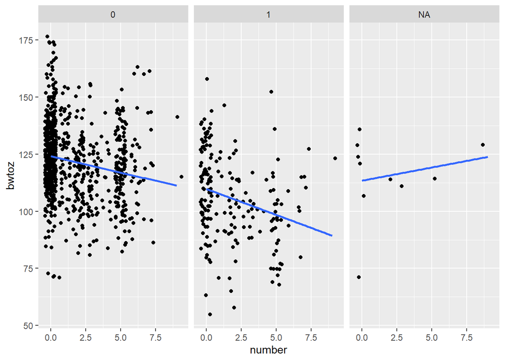

```r
ggplot(data=babies, mapping=aes(x=number, y=bwtoz))+geom_jitter()+facet_wrap(~ Premature)+ geom_smooth(method='lm', se=FALSE)
```

**Drew Individual Graph**

The data shown depicts the relationship between gestation period in days and the weight at birth in ounces. It is then divided between smokers and non-smokers. As you can see from the slope of the regression lines, low birthweight for smoking mothers has a much more pronounced effect on premature babies, those who have spent less than 270 days in the womb. The distribution of points is lower for the smokers section.

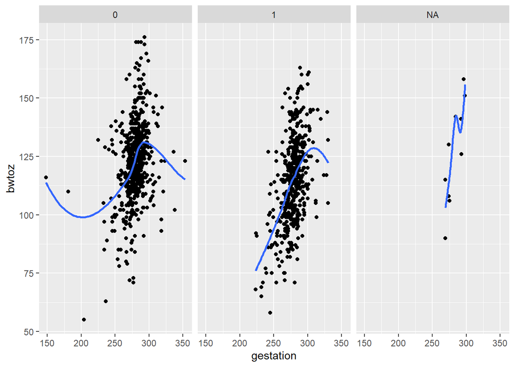

```r
ggplot(data = babies, mapping = aes(x = gestation, y = bwtoz)) + geom_point() + geom_smooth(se = FALSE) + facet_wrap(~smoke)
```

**Brandon Individual Graph**

I created a scatter plot of a mother’s weight at pregnancy and a babies weight at pregnancy to distinguish if a heavier birth weight correlated to a heavier baby at birth, I uesd geom_point and geom_smooth to create this scatter plot with a regression line. I also converted premature into a boolean using as.factor, this allowed me to graph premature by color and not as a scale. I then used guides and theme to fix up the legend. It is seen that just because a baby is premature it does not have to be underweight and there can be underweight babies born during normal gestation periods.

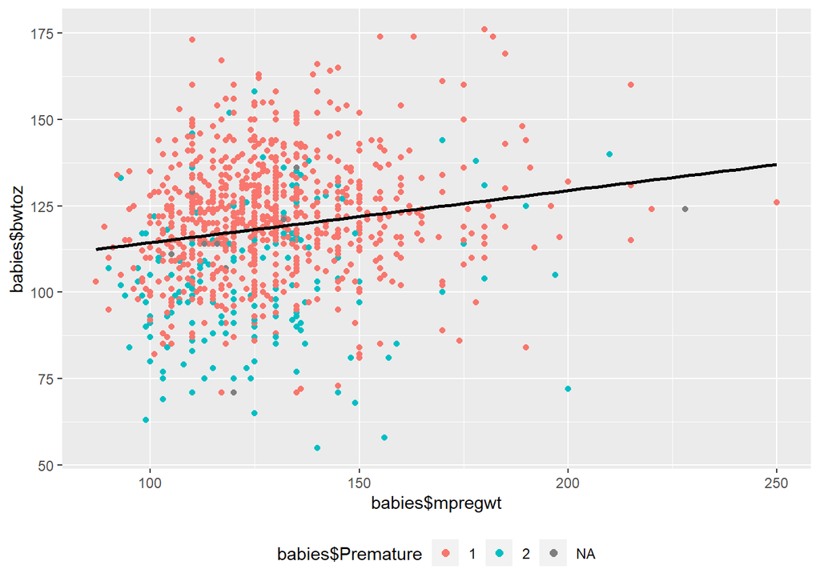

```r
babies$Premature <- as.numeric(babies$Premature)
babies$Premature <- as.factor(babies$Premature)
ggplot(data = babies)+
  geom_point(mapping = aes(x = babies$mpregwt, y = babies$bwtoz, color = babies$Premature))+
  theme(legend.position = "bottom")+
  guides(color = guide_legend(nrow = 1, override.aes = list(size = 2)))+
  geom_smooth(mapping = aes(x = babies$mpregwt, y = babies$bwtoz), se = FALSE, method = 'lm', color = "black")
```

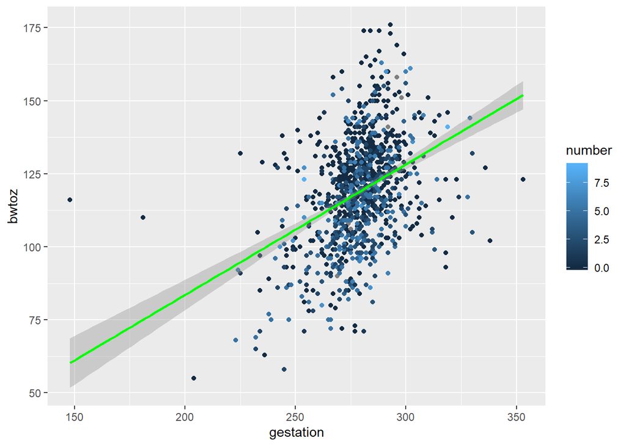

```r
ggplot(data = babies, aes(x = gestation, y = bwtoz, color = number)) +
  geom_point() +
  geom_smooth(method = lm, color = "green")
```

[figure not shown]

**6. Who Did What:**

Burke - Team plot one

David - Overall Questions

Tanner - Recommendation

Drew - Preliminary question

Brandon - Formatting, Merge Fixes, Team plot two